# demo_improved_9/17

Henry He

2020/9/17

- Load Data The file res.RDS will be loaded into a `list` called `res` Entries of the list will then be extracted and seperately stored

```r
filedir = "~/Downloads/for-henry/res.RDS"
## filedir = "C:/Users/Administrator/Documents/GitHub/flowcy-shiny/learning-plotly/res.RDS"
res = readRDS(filedir)

countslist = res$countslist

ylist = res$ylist

mn = res$mn

numclust = res$numclust

TT = length(ylist)

Time <- names(ylist)
```

Read Data

function: form_pie_table

The `pie` entry of `res` will be extracted, and stored in a new dataframe called pie_table.

Parameter: list `res` Return : a number dependent on res data x 3 dataframe Pie table has three columns : Time: Indicating the time associated with the row Cluster: Which cluster it belongs to Prob: The `pie` value extracted from the table

```r
##' @param res: A list containing the resulting data from model
##' @return pie_table : data.frame with TT rows and 3 columns
form_pie_table <- function(res){
  pie_table <- data.frame(res$pie)
  pie_table <- setDT(pie_table, keep.rownames = "Time")[]
  colnames(pie_table) <- c("Time", paste0("cluster_", 1:10))
## Reshape it to 3 columns as described above
  pie_table <- pie_table%>%
  gather(var,val,-c(1))%>%
  separate(var,c("type","cluster"))%>%
  .[-2]
  colnames(pie_table) <- c("Time", "Cluster","Prob")
  return(pie_table)
}
pie_table = form_pie_table(res)
head(pie_table)
```

[output not shown]

2. mn(cluster means) function : form_mn_table Extract `mn` values from 'res' and stored in a new dataframe called mn_table

```r
##' @param res: A list containing the resulting data from model
##' @return _table : data.frame with TT rows and 3 columns
form_mn_table <- function(res){
  dfs = lapply(1:numclust, function(iclust){
  one_table = tibble(diam_mid_pie = mn[,1,iclust],
                     chl_small_pie = mn[,1,iclust],
                     pe_pie = mn[,1,iclust],
                     Time = Time, Cluster = rep(iclust, TT))
  colnames(one_table)[1:3] <- c("diam_mid_pie","chl_small_pie","pe_pie")
  one_table
  })
  mn_table = bind_rows(dfs)
  return(mn_table)
}
mn_table = form_mn_table(res)
```

Combine two dataframe Thoughts, two dataframe both contained column Cluster, and later our objective is to highlight date based on Cluster. It make sense to merge two dataframe into one insteading of keeping them seperately function Note : Time,Cluster columns in two dataframe are identical, we only keep one in our new table.

```r
clustered_data_table = merge(pie_table,mn_table)
head(clustered_data_table)
```

[output not shown]

In order to plot this three dimensional data, we will store ylist into three sub-dataframes each contains two of the three dimensions Function : convert_ylist_2d (better name) parameter: ylist return : Three data_frames each containg two of the dimension of ylist

```r
## Function from flowmix file
collapse_3d_to_2d <- function(y, counts, dims=1:2){

  ## Basic checks
  stopifnot(all(dims %in% 1:3))
  stopifnot(length(dims)==2)

  ## Aggregate
  ymat = cbind(y[,dims], counts) %>% as.data.frame()
  names(ymat)[1:2] = c("dim1", "dim2")
  ymat_summary <- ymat %>% group_by(dim1, dim2) %>% summarise(counts=sum(counts)) %>% as.matrix

  ## Basic check
  if(!is.null(colnames(y))){
    colnames(ymat_summary)[1:2] = colnames(y)[dims]
  }

  return(ymat_summary)
}

##' @param ylist: A list containing the resulting data from ylist in res
##' @param table_list: A list of table (dimension choose 2) data frames. The deafult ordering will be...(to be determined)
convert_ylist_2d <- function(ylist){
  ## Setup
  alltimes = names(ylist)
  TT = length(ylist)
  tablist = list()
  dimslist = list(c(1,2), c(2,3), c(3,1))

  ## Obtain all the tables once.
  for(ii in 1:length(dimslist)){

    dims = dimslist[[ii]]

    ## Form the table
    all_2d_tables = lapply(1:TT, function(tt){
      y = ylist[[tt]][,dims]
      counts = countslist[[tt]]
      collapse_3d_to_2d(y, counts, dims=1:2)
    })
    combined_2d_table = do.call(rbind, all_2d_tables) %>% as_tibble()

    ## Add time
    reptimes = sapply(all_2d_tables, nrow)
    times = rep(alltimes, reptimes)
    combined_2d_table[,"Time"] = times
    newname = paste0("counts_", ii)
    combined_2d_table <- rename(combined_2d_table, !!newname:=counts)
    tablist[[ii]] = combined_2d_table
  }
  diam_chl_table <- tablist[[1]]
  pe_chl_table <- tablist[[2]]
  diam_pe_table <- tablist[[3]]
  return(list(diam_chl_table,pe_chl_table,diam_pe_table))
}
table_list = convert_ylist_2d(ylist)
```

- Plot

```r
# Colors
# how to choose color?
# This is set of color is chosen by hand with numclust known to be 10. In general, this should be replaced by
# a set of colors with length = numclust whose element are chosen from ...(Need to set a range for color)
myColor = c("red","green","orange","blue","brown","deeppink","navyblue","orchid","seagreen","gold")

key <- highlight_key(clustered_data_table,~Cluster)

# create highlight key, which highlights by cluster
pie_plot <- plot_ly(key)%>%
  group_by(Cluster)%>%
  add_lines(x = ~Time , y = ~Prob, color = ~Cluster, colors = myColor ,)%>%
  add_segments(x = ~Time, xend = ~Time, y = 0, yend = 1, frame = ~Time,showlegend = FALSE, color = "red",showlegend = FALSE)

# modify the x-axis
pie_plot <- pie_plot%>%layout(
  xaxis = list(
    type = "date",
    tickformat = "%d%M%Y",showticklabels = FALSE)
)
pie_plot
```

[output not shown]

```r
p1 <- plot_ly(as.data.frame(table_list[1]),
              x = ~diam_mid,
              y = ~chl_small,
              size = ~ counts_1,
              type = 'scatter',
              mode = 'markers',
              sizes = c(0,1000),
              opacity = 0.5,
              alpha = 0.3,
              showlegend = FALSE) %>%
  add_trace(data = key,
            x = ~diam_mid_pie,
            y = ~chl_small_pie,
            frame = ~Time,
            size = 5,
            hoverinfo = 'text',
            text = ~paste("Cluster", Cluster),
            hovertext = ~paste("Cluster", Cluster),
            textposition = "bottom center",
            mode = 'markers+text',
            textfont = list(size = 14),
            opacity = 0.9)
p2 <- plot_ly(as.data.frame(table_list[2]),
              x = ~pe,
              y = ~chl_small,
              size = ~ counts_2,
              type = 'scatter',
              mode = 'markers',
              alpha = 0.3,
              opacity=0.5,
              sizes = c(0,1000),
              showlegend = FALSE)%>%
  add_trace(data = key,
            x = ~pe_pie,
            y = ~chl_small_pie,
            frame = ~Time,
            showlegend = FALSE,
            size = 5,
            hoverinfo = 'text',
            text = ~paste("Cluster",Cluster),
            hovertext = ~paste("Cluster",Cluster),
            textposition = "bottom center",
            mode = 'markers+text',
            textfont = list(size = 14),
            opacity = 0.9
            )

p3<-plot_ly(as.data.frame(table_list[2]),
            x= ~diam_mid,
            y = ~pe,
            size = ~ counts_3,
            type = 'scatter',
            mode = 'markers',
            opacity=0.5,
            sizes = c(0,1000),
            alpha = 0.3,
            showlegend = FALSE)%>%
  add_trace(data = key,
            x = ~diam_mid_pie,
            y = ~pe_pie,
            frame = ~Time,
            size = 5,
            hoverinfo = 'text',
            text = ~paste("Cluster",Cluster),
            hovertext = ~paste("Cluster",Cluster),
            textposition = "bottom center",
            mode = 'markers+text',
            textfont = list(size = 14),
            opacity = 0.9
            )
scatterplot <- subplot(p1,p2,p3,shareX = TRUE,shareY = TRUE)
scatterplot
```

[output not shown]

# Justin's suggestions

First of all, the quality/readability of the code, and function definitions + documentation are all greatly improved! Good job on this.

## Some lower-level to-do items

(**Please include these items in your update emails.**):

- (High priority, within next few days) Make sure that you can load the package. (Try pulling again from the master branch of flowmix; I've gotten rid of the C++ code from the master branch.)
- This Rmd file is not runnable (See my later comment about this)
- When I make some small fixes and run it, your `p1` doesn't look like what we want

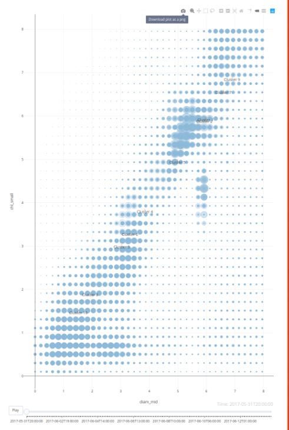

## Some higher level items:

- I'd like you to maintain your helper functions in an R file, called `viz.R`, in this repository (by the way, when we get to the point where we have too many functions for a single file, we'll of course expand to several files; see my next point). This way, we don't have the R functions scattered in the Rmd files, which are not meant to be static locations for the function definitions to reside.
- Eventually, we'll want to add your files into an R package, named "flowmix-viz", in the flowmix github repository. For a short blog post on how to make your first R package, there are many resources out there, like [this blog post](https://tinyheero.github.io/jekyll/update/2015/07/26/making-your-first-R-package.html). Let's cross this bridge when we come to it!
- The advantage of having things in an R package is that when we are writing scripts using our helper functions, we just need to run `library(flowmix-viz)` or `load_all("C:/Users/Administrator/Desktop/flowmix-master/flowmix')` and all the functions are encapsulated.

## Some project organization items:

- This Rmd file is not runnable. I've asked about this before, but could you always double check whether the file renders *on its own* (i.e. the "knit" button in Rstudio), and also upload an accompanying html output file? Recall the same point made in `demo_8_27_with_suggestions.Rmd`:

> This document is clearly not knittable. That's, in general, the whole point of using R Markdown -- you have a single ".Rmd" file that you can knit to **reproduce** your data analysis. I should be able to hit "knit" (Ctrl+Shift+K) in my Rstudio and be able to produce a complete document; the same one as yours. From hereon, when you share Rmd documents, could you make sure that these are completely knittable.
- Also, see https://rmarkdown.rstudio.com/authoring_basics.html for how to make cleaner Rmd files, with proper headers and subheaders and links, **bold faced** and *italics*, quotes and `code`. You can also start by mimicking my "learning-plotly.Rmd" style.
- The cleanness and completeness of these Rmd files is **super important** since this is the primary way we communicate -- especially we only meet 30 minutes a week. If you just scroll up (screenshot attached next), you can see that the document is not nearly at a finishing quality of even a homework assignment. You should think of these R markdown documents as your periodic job progress report -- surely if you were reporting to your boss, you would want to have your report made in complete sentences and narrated coherently, formatted consistently, and you would also want to polish the report so that you can convey clearly what you've done. Your current document looks like this:

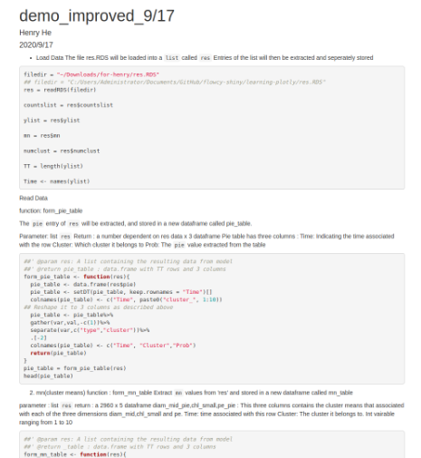

- I realize some of my suggestions are slipping through the cracks. It's important to keep track of detailed todo items, especially since ours is largely a software implementation project.
- Moving forward, can you write me a short weekly email before our meeting? This email would contain:
  - The summary (just a few sentences is fine) for what you've done so this week.
  - Todo items that you've finished this week.
  - Todo items that were (roughly in priority order, if applicable).